# draft

# Exploratory analysis

```r
summary(data)
```

## splitting data into train and test/validation

```r
set.seed(67)
train_indices <- sample(1:10000,8000)
train_data <- data[train_indices, ]
test_data <- data[-train_indices, ]


train_data_x <- train_data %>% dplyr::select(-OUTCOME, -CLAIMS)
test_data_x <- test_data %>% dplyr::select(-OUTCOME, -CLAIMS)
```

## correlation matrix of numeric covariates

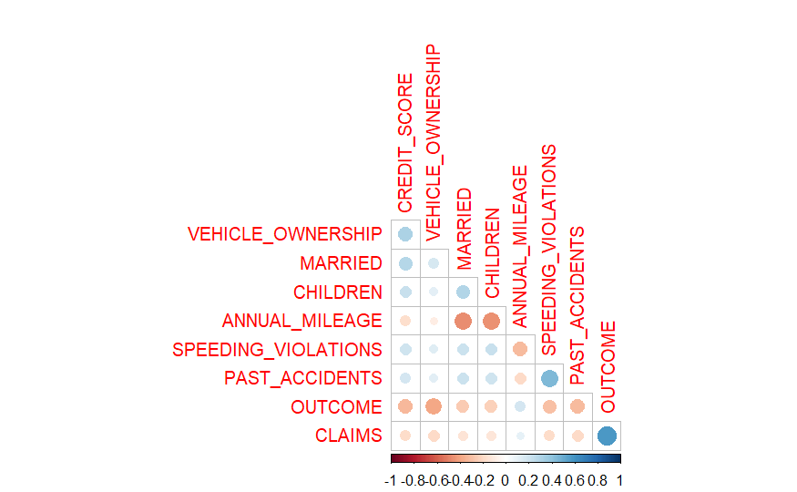

```r
num_cols <-  data %>% select(where(is.numeric))

num_cols <-  num_cols[!is.na(num_cols$CREDIT_SCORE) &
                      !is.na(num_cols$ANNUAL_MILEAGE),]
num_cols <-  num_cols %>% select(-ID)
corrplot(cor(num_cols), type = "lower", diag = F)
```

- Annual mileage is lower for married ppl and ppl with children
- past accidents has high corr with speeding violations ofc
- vehicle owners are less likely to file claims?

## investigating missing values

```r
print(paste("number of rows with missing annual mileage",
            sum(is.na(train_data$ANNUAL_MILEAGE)), "/8000"))
```

```
[1] "number of rows with missing annual mileage 773 /8000"
```

```r
print(paste("number of rows with missing creditscore",
            sum(is.na(train_data$CREDIT_SCORE)), "/8000"))
```

```
[1] "number of rows with missing creditscore 804 /8000"
```

```r
print(paste("number of rows missing both annual mileage and credit",
            sum(is.na(train_data$ANNUAL_MILEAGE) & is.na(train_data$CREDIT_SCORE)), "/8000"))
```

```
[1] "number of rows missing both annual mileage and credit 76 /8000"
```

```r
print(paste("percentage of ppl of claim for nonempty annual mileage rows",
            mean(train_data[!is.na(train_data$ANNUAL_MILEAGE),"OUTCOME", drop = T])))
```

```
[1] "percentage of ppl of claim for nonempty annual mileage rows 0.31451501314515"
```

```r
print(paste("percentage of ppl of claim for empty annual mileage rows",
            mean(train_data[is.na(train_data$ANNUAL_MILEAGE),"OUTCOME", drop = T])))
```

```
[1] "percentage of ppl of claim for empty annual mileage rows 0.33764553686934"
```

```r
print(paste("percentage of ppl of claim for nonempty creditscore rows",
            mean(train_data[!is.na(train_data$CREDIT_SCORE),"OUTCOME", drop = T])))
```

```
[1] "percentage of ppl of claim for nonempty creditscore rows 0.317259588660367"
```

```r
print(paste("percentage of ppl of claim for empty creditscore rows",
            mean(train_data[is.na(train_data$CREDIT_SCORE),"OUTCOME", drop = T])))
```

```
[1] "percentage of ppl of claim for empty creditscore rows 0.312189054726368"
```

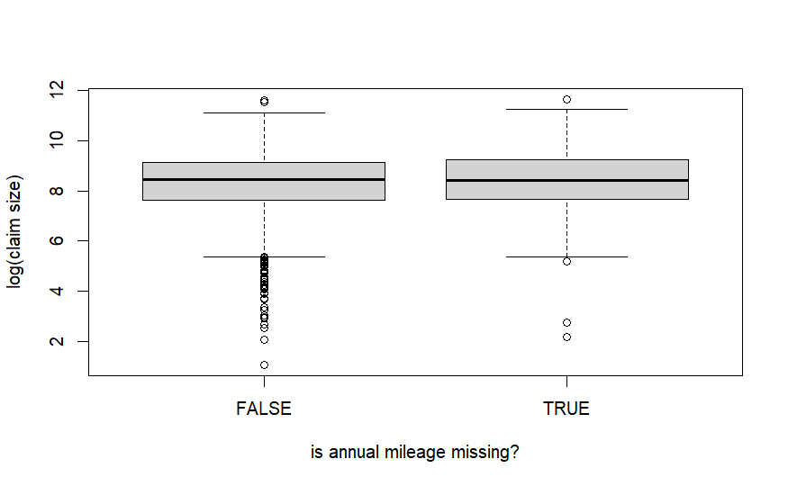

```r
boxplot(log(train_data[train_data$CLAIMS>0,"CLAIMS", drop = T]) ~ is.na(train_data[train_data$CLAIMS>0,"ANNUAL_MILEAGE", drop = T]),
        xlab = "is annual mileage missing?", ylab = "log(claim size)")
```

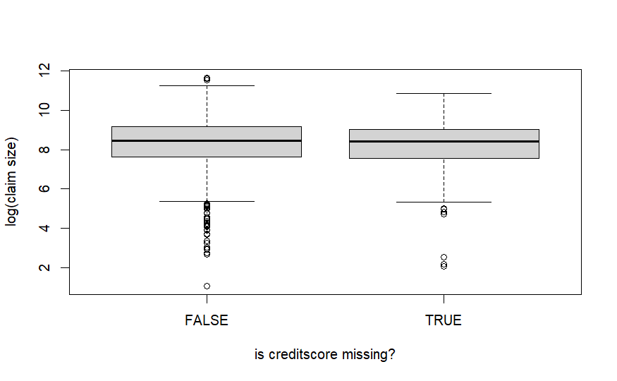

```r
boxplot(log(train_data[train_data$CLAIMS>0,"CLAIMS", drop = T]) ~ is.na(train_data[train_data$CLAIMS>0,"CREDIT_SCORE", drop = T]),
        xlab = "is creditscore missing?", ylab = "log(claim size)")
```

- Dont want to get rid of ~10% of the data, would be good to impute

Investigating if emptiness of the creditscore is independent to other variables i.e if creditscore is intentionally left empty - would expect younger ppl to have no credit score, so cells may be intentionally empty

```r
print("TESTING FOR INDEPENDENCE OF CREDIT_SCORE EMPTINESS")
```

```
[1] "TESTING FOR INDEPENDENCE OF CREDIT_SCORE EMPTINESS"
```

```r
# Define the target variable: a binary indicator for missing credit scores
credit_score_missing <- is.na(train_data$CREDIT_SCORE)

# Get a list of all predictor variables to test, excluding ID and CREDIT_SCORE itself
predictors_to_test <- setdiff(names(train_data), c("ID", "CREDIT_SCORE"))

# Loop through each predictor and perform the appropriate test
for (var in predictors_to_test) {

  # Ignore any columns with no variation
  if (length(unique(train_data[[var]])) < 2) next

  # --- Test for association with CONTINUOUS variables ---
  if (is.numeric(train_data[[var]])) {
    # We use a t-test to see if the mean of the numeric variable is
    # different between the 'missing' and 'present' groups.
    test_result <- t.test(train_data[[var]] ~ credit_score_missing)
    p_value <- test_result$p.value
    cat(sprintf("Variable: %-20s | Test: T-test         | P-value: %.4f\n", var, p_value))

  # --- Test for association with CATEGORICAL variables ---
  } else if (is.factor(train_data[[var]]) || is.character(train_data[[var]])) {
    # We use a Chi-squared test for independence between two categorical variables.
    # We add 'simulate.p.value = TRUE' to handle cases with low expected counts.
    test_result <- chisq.test(table(train_data[[var]], credit_score_missing), simulate.p.value = TRUE)
    p_value <- test_result$p.value
    cat(sprintf("Variable: %-20s | Test: Chi-squared    | P-value: %.4f\n", var, p_value))
  }
}
```

```
Variable: AGE                  | Test: Chi-squared    | P-value: 0.1544
Variable: GENDER               | Test: Chi-squared    | P-value: 0.9025
Variable: DRIVING_EXPERIENCE   | Test: Chi-squared    | P-value: 0.1494
Variable: EDUCATION            | Test: Chi-squared    | P-value: 0.5927
Variable: VEHICLE_OWNERSHIP    | Test: T-test         | P-value: 0.1828
Variable: VEHICLE_YEAR         | Test: Chi-squared    | P-value: 0.0395
Variable: MARRIED              | Test: T-test         | P-value: 0.4997
Variable: CHILDREN             | Test: T-test         | P-value: 0.4530
Variable: ANNUAL_MILEAGE       | Test: T-test         | P-value: 0.6424
Variable: VEHICLE_TYPE         | Test: Chi-squared    | P-value: 0.4308
Variable: SPEEDING_VIOLATIONS  | Test: T-test         | P-value: 0.7981
Variable: PAST_ACCIDENTS       | Test: T-test         | P-value: 0.9907
Variable: OUTCOME              | Test: T-test         | P-value: 0.7688
Variable: CLAIMS               | Test: T-test         | P-value: 0.1725
```

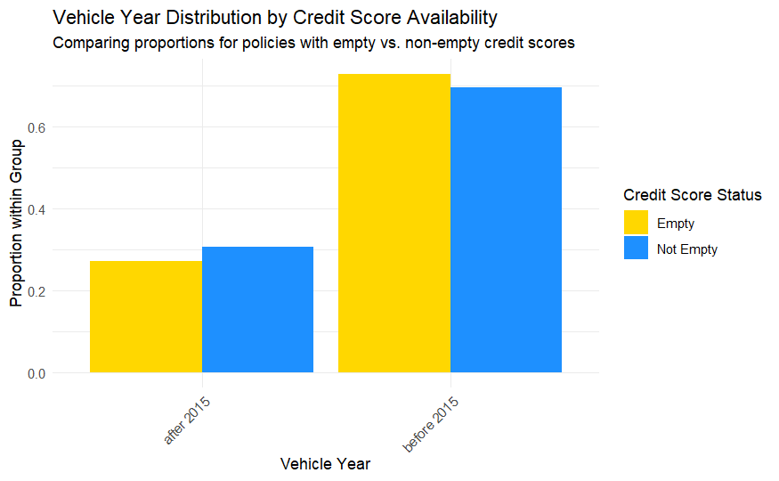

```r
plot_data <- train_data %>%
  # Create a clear factor for whether the credit score is missing
  mutate(Credit_Score_Status = factor(ifelse(is.na(CREDIT_SCORE), "Empty", "Not Empty"))) %>%
  # Count the occurrences of each vehicle year for each status
  count(VEHICLE_YEAR, Credit_Score_Status) %>%
  # Group by the status so we can calculate proportions within each group
  group_by(Credit_Score_Status) %>%
  # Calculate the proportion
  mutate(Proportion = n / sum(n))


# --- 4. Create the Side-by-Side Bar Plot ---

ggplot(plot_data, aes(x = VEHICLE_YEAR, y = Proportion, fill = Credit_Score_Status)) +
  # geom_bar with stat="identity" uses the y-value directly.
  # position="dodge" places the bars next to each other.
  geom_bar(stat = "identity", position = "dodge") +

  labs(
    title = "Vehicle Year Distribution by Credit Score Availability",
    subtitle = "Comparing proportions for policies with empty vs. non-empty credit scores",
    x = "Vehicle Year",
    y = "Proportion within Group",
    fill = "Credit Score Status"
  ) +

  # Set the colors as requested
  scale_fill_manual(values = c("Empty" = "gold", "Not Empty" = "dodgerblue")) +

  # Improve readability
  theme_minimal() +
  theme(axis.text.x = element_text(angle = 45, hjust = 1))
```

- with no particular reason to take the conventional significance level of 0.05, conclude that the vehicle year is still independent to the emptiness of credit scores
- suggests that ppl with no credit score are not necessarily younger, so we assume that missing values are missing unintentionally

```r
print("TESTING FOR INDEPENDENCE OF ANNUAL_MILEAGE EMPTINESS")
```

```
[1] "TESTING FOR INDEPENDENCE OF ANNUAL_MILEAGE EMPTINESS"
```

```r
AM_missing <- is.na(train_data$ANNUAL_MILEAGE)

# Get a list of all predictor variables to test, excluding ID and CREDIT_SCORE itself
predictors_to_test <- setdiff(names(train_data), c("ID", "ANNUAL_MILEAGE"))

# Loop through each predictor and perform the appropriate test
for (var in predictors_to_test) {

  # Ignore any columns with no variation
  if (length(unique(train_data[[var]])) < 2) next

  # --- Test for association with CONTINUOUS variables ---
  if (is.numeric(train_data[[var]])) {
    # We use a t-test to see if the mean of the numeric variable is
    # different between the 'missing' and 'present' groups.
    test_result <- t.test(train_data[[var]] ~ AM_missing)
    p_value <- test_result$p.value
    cat(sprintf("Variable: %-20s | Test: T-test         | P-value: %.4f\n", var, p_value))

  # --- Test for association with CATEGORICAL variables ---
  } else if (is.factor(train_data[[var]]) || is.character(train_data[[var]])) {
    # We use a Chi-squared test for independence between two categorical variables.
    # We add 'simulate.p.value = TRUE' to handle cases with low expected counts.
    test_result <- chisq.test(table(train_data[[var]], AM_missing), simulate.p.value = TRUE)
    p_value <- test_result$p.value
    cat(sprintf("Variable: %-20s | Test: Chi-squared    | P-value: %.4f\n", var, p_value))
  }
}
```

```
Variable: AGE                  | Test: Chi-squared    | P-value: 0.4203
Variable: GENDER               | Test: Chi-squared    | P-value: 0.8166
Variable: DRIVING_EXPERIENCE   | Test: Chi-squared    | P-value: 0.5192
Variable: EDUCATION            | Test: Chi-squared    | P-value: 0.6092
Variable: CREDIT_SCORE         | Test: T-test         | P-value: 0.3480
Variable: VEHICLE_OWNERSHIP    | Test: T-test         | P-value: 0.5202
Variable: VEHICLE_YEAR         | Test: Chi-squared    | P-value: 0.2689
Variable: MARRIED              | Test: T-test         | P-value: 0.8048
Variable: CHILDREN             | Test: T-test         | P-value: 0.4170
Variable: VEHICLE_TYPE         | Test: Chi-squared    | P-value: 0.4728
Variable: SPEEDING_VIOLATIONS  | Test: T-test         | P-value: 0.5506
Variable: PAST_ACCIDENTS       | Test: T-test         | P-value: 0.0999
Variable: OUTCOME              | Test: T-test         | P-value: 0.1960
Variable: CLAIMS               | Test: T-test         | P-value: 0.1095
```

- pvalues very high, so likely that annual_mileage is left empty independently of other variables
- assume from here on that missing values are missing unintentionally

## imputing missing values

```r
# 1. Select all numeric columns from train and test sets
train_numeric <- train_data_x %>% select(where(is.numeric))
test_numeric  <- test_data_x %>% select(where(is.numeric))

# 2. Build recipe: Impute ONLY ANNUAL_MILEAGE and CREDIT_SCORE, using all numeric predictors
rec <- recipe(~ ., data = train_numeric) %>%
  step_impute_knn(c("ANNUAL_MILEAGE", "CREDIT_SCORE"))

# 3. Prep the recipe (fit on training data)
rec_prep <- prep(rec, training = train_numeric)

# 4. Impute the training and test sets
train_imputed <- bake(rec_prep, new_data = train_numeric)
test_imputed  <- bake(rec_prep, new_data = test_numeric)

# The result: train_imputed and test_imputed contain all numeric columns,
# with only ANNUAL_MILEAGE and CREDIT_SCORE imputed, using relationships with all numeric variables.

train_data_imputed <- train_data
train_data_imputed$ANNUAL_MILEAGE <- train_imputed$ANNUAL_MILEAGE
train_data_imputed$CREDIT_SCORE <- train_imputed$CREDIT_SCORE

test_data_imputed <- test_data
test_data_imputed$ANNUAL_MILEAGE <- test_imputed$ANNUAL_MILEAGE
test_data_imputed$CREDIT_SCORE <- test_imputed$CREDIT_SCORE
```

- used PCA between numeric variables to impute missing values
- wasnt possible to use the same model to also impute test data
- used knn imputation instead
- doesnt account for categorical variable values!

## histogram of covariates

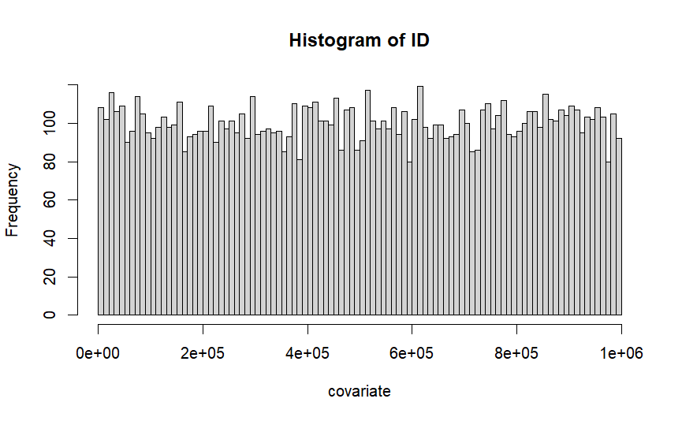

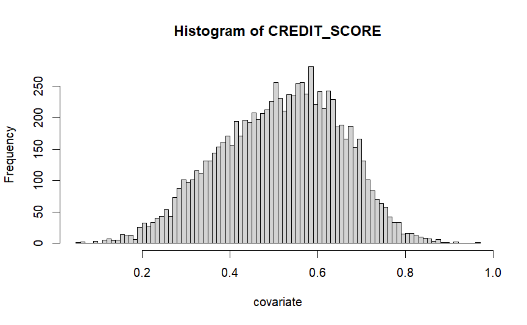

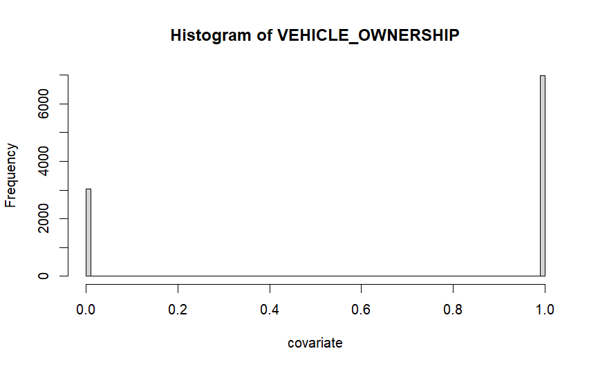

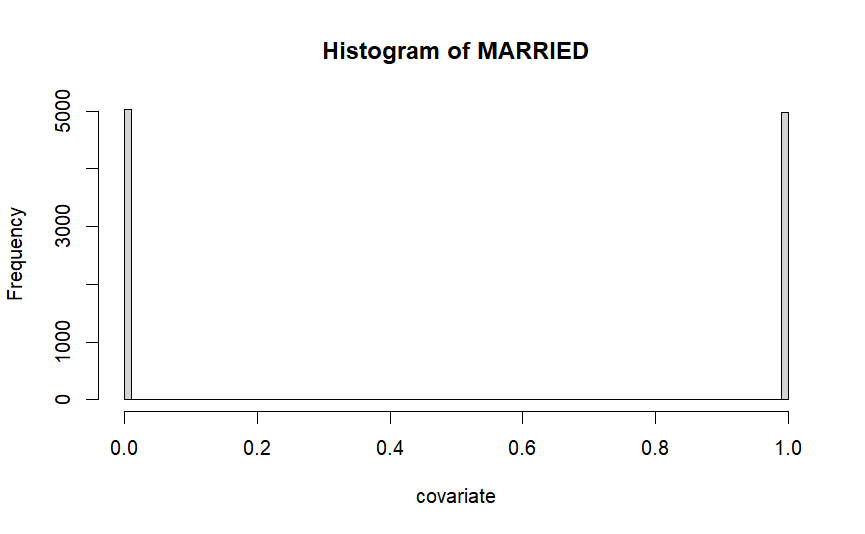

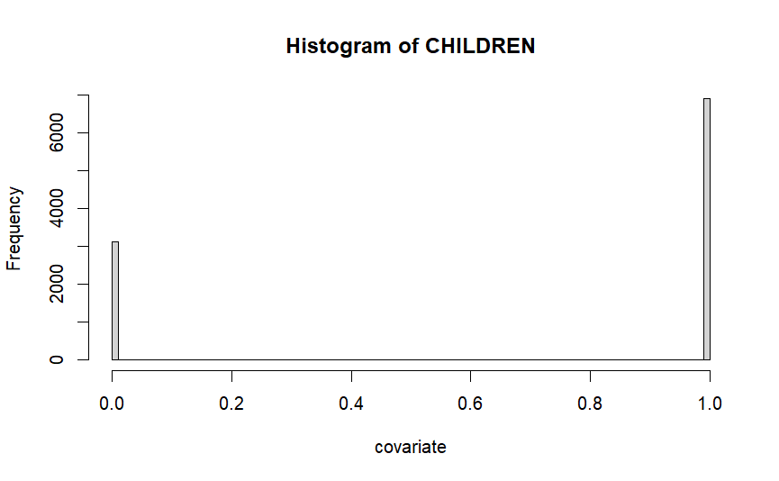

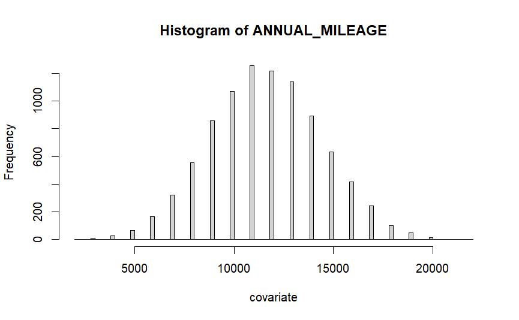

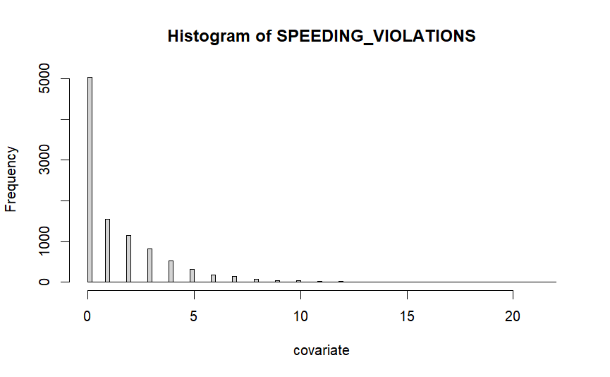

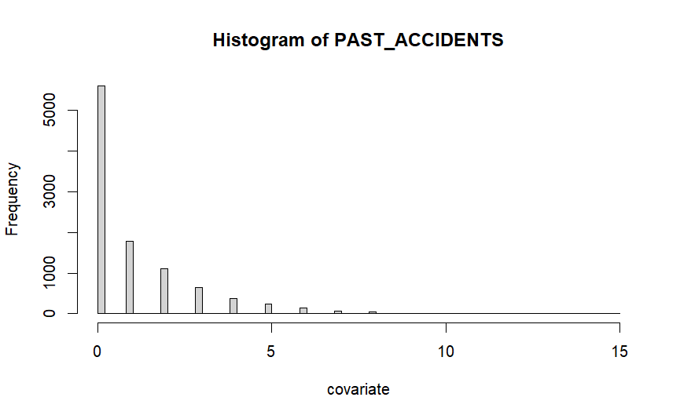

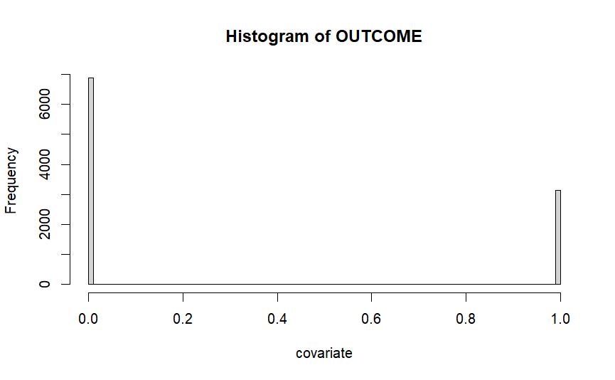

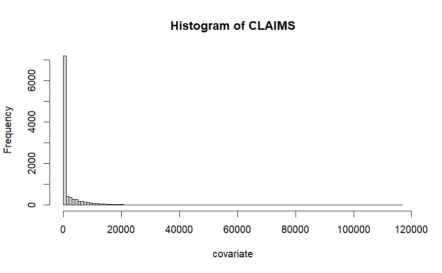

```r
for (i in 1:length(data)){
  covariate <- data[[i]]
  if (is.numeric(covariate)){
    hist(covariate, main = paste("Histogram of", names(data)[i] ), xlab = deparse(substitute(covariate)), breaks = 100)
  }
}
```

```r
summary(train_data)
```

```
       ID            AGE          GENDER     DRIVING_EXPERIENCE
 Min.   :   125   16-25:1611   female:3993   0-9y  :2822
 1st Qu.:249025   26-39:2459   male  :4007   10-19y:2641
 Median :500664   40-64:2339                 20-29y:1688
 Mean   :499893   65+  :1591                 30y+  : 849
 3rd Qu.:753723
 Max.   :999976

       EDUCATION     CREDIT_SCORE     VEHICLE_OWNERSHIP      VEHICLE_YEAR
 high school:3335   Min.   :0.05336   Min.   :0.000     after 2015 :2416
 none       :1524   1st Qu.:0.41637   1st Qu.:0.000     before 2015:5584
 university :3141   Median :0.52456   Median :1.000
                    Mean   :0.51528   Mean   :0.695
                    3rd Qu.:0.61700   3rd Qu.:1.000
                    Max.   :0.96082   Max.   :1.000
                    NA's   :804
    MARRIED          CHILDREN      ANNUAL_MILEAGE      VEHICLE_TYPE
 Min.   :0.0000   Min.   :0.0000   Min.   : 3000   sedan     :7623
 1st Qu.:0.0000   1st Qu.:0.0000   1st Qu.:10000   sports car: 377
 Median :0.0000   Median :1.0000   Median :12000
 Mean   :0.4951   Mean   :0.6871   Mean   :11723
 3rd Qu.:1.0000   3rd Qu.:1.0000   3rd Qu.:14000
 Max.   :1.0000   Max.   :1.0000   Max.   :22000
                                   NA's   :773
 SPEEDING_VIOLATIONS PAST_ACCIDENTS      OUTCOME           CLAIMS
 Min.   : 0.000      Min.   : 0.000   Min.   :0.0000   Min.   :     0
 1st Qu.: 0.000      1st Qu.: 0.000   1st Qu.:0.0000   1st Qu.:     0
 Median : 0.000      Median : 0.000   Median :0.0000   Median :     0
 Mean   : 1.484      Mean   : 1.055   Mean   :0.3167   Mean   :  2360
 3rd Qu.: 2.000      3rd Qu.: 2.000   3rd Qu.:1.0000   3rd Qu.:  1838
 Max.   :22.000      Max.   :15.000   Max.   :1.0000   Max.   :116328
```

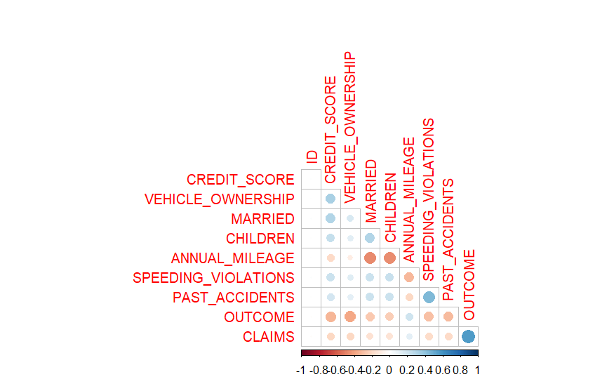

```r
num_cols = train_data_imputed %>% select_if(is.numeric)
cor_matrix = cor(num_cols)
corrplot(cor_matrix, type = "lower", diag = F)
```

- looks like annual mileage has a negative correlation with being married / having children
- ppl with speeding violations are much more likely to have past accidents
- surprisingly non vehicle owners have a higher correlation with making claims

# investigation of claim sizes

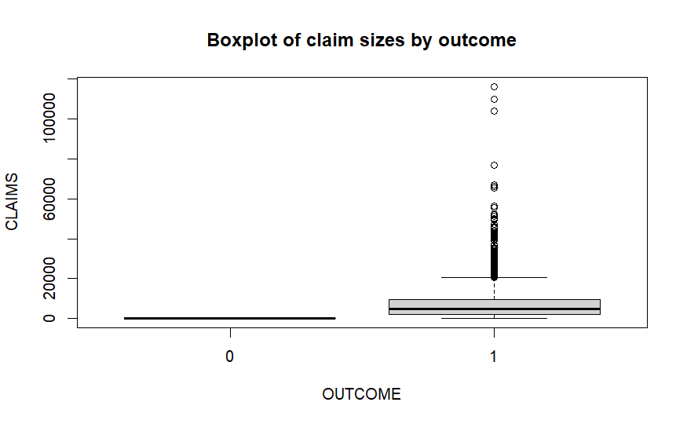

```r
boxplot(train_data_imputed$CLAIMS ~ train_data_imputed$OUTCOME,
        main = "Boxplot of claim sizes by outcome", xlab = "OUTCOME", ylab = "CLAIMS")
```

```r
sum(train_data_imputed[train_data_imputed$OUTCOME == 0, "CLAIMS"])
sum(train_data_imputed[train_data_imputed$CLAIMS == 0, "OUTCOME"])
```

[output not shown]

- Looks like there are no cases where outcome = 1 and there is a claimsize of 0
- suggests that claims sizes are always nonzero and zero claims should be accounted for within the counts distribution

## Extreme value analysis of claimsizes

```r
nonzerosizes <- data[data$OUTCOME>0, "CLAIMS", drop = T]
quantile(nonzerosizes, c(0.95,0.97, 0.99, 0.995))
```

```
     95%      97%      99%    99.5%
23303.06 29080.47 42786.68 51570.25
```

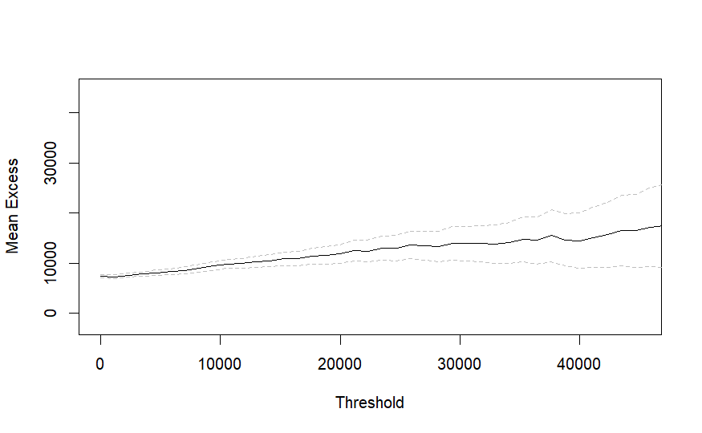

```r
# mean excess plot
mrlplot(nonzerosizes, xlim = c(0,45000))
```

- Mean excess function is rising, clearly a heavy tailed distribution

```r
# Fitting GEV distribution
block_size <- 50
blocks <- ceiling(seq_along(nonzerosizes) / block_size)
GEVdf <- data.frame(nonzerosizes, blocks)
block_maxima_df <- GEVdf %>%
  group_by(blocks) %>%
  summarise(
    max_claim = max(nonzerosizes)
  )
gev_fit <- extRemes::fevd(block_maxima_df$max_claim)
summary(gev_fit)
```

```
extRemes::fevd(x = block_maxima_df$max_claim)

[1] "Estimation Method used: MLE"


 Negative Log-Likelihood Value:  695.5335


 Estimated parameters:
    location        scale        shape
3.312419e+04 1.112776e+04 2.191021e-01

 Standard Error Estimates:
   location       scale       shape
1591.904652 1247.447031    0.101009

 Estimated parameter covariance matrix.
              location         scale        shape
location 2534160.42263  1.131005e+06 -50.31878400
scale    1131004.89478  1.556124e+06  -6.45730616
shape        -50.31878 -6.457306e+00   0.01020283

 AIC = 1397.067

 BIC = 1403.496
```

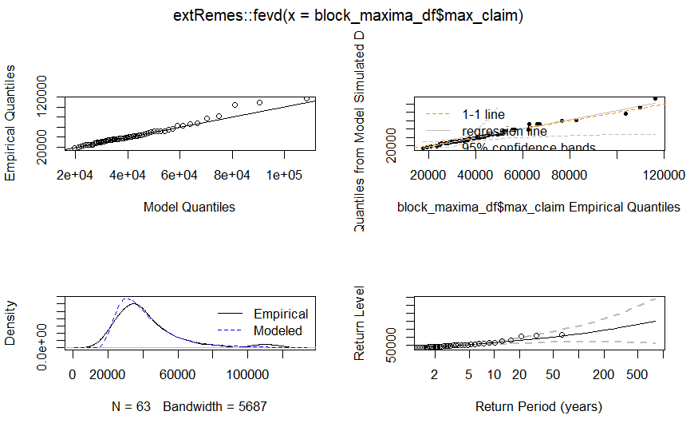

```r
plot(gev_fit)
```

```r
# Hypothesis test with H0: shape = 0
# Assuming a normal distribution of the shape parameter estimator
shape.estimate <- 0.219102
shape.stderr <- 0.101009

print(shape.estimate/shape.stderr)
```

```
[1] 2.169133
```

- clearly, the shape parameter is significantly different from 0, so we can reject the null hypothesis of an exponential tail. It is quite obvious that we have a frechet type distribution of the nonzero claim sizess
- Suggests use of frechet family
- Could use gamma or lognormal from the exponential family